# W200 Final Project Proposal

# US foreign aid spending and the diffusion of democracy

## *Has US foreign aid spending coincided with global democratic development?*

- Silas Everett
- Alex Herring
- December 13, 2017

# About the Data

> - U.S. Foreign Aid - https://explorer.usaid.gov/data.html
> - Freedom House - https://freedomhouse.org/report/fiw-2017-table-country-scores
> - World Bank (wbdata API) - https://wbdata.readthedocs.io/en/latest/
> - FIPS codes CIA fact book https://www.cia.gov/library/publications/the-world-factbook/appendix/appendix-d.html

```python
print('Shape after merge: {} rows {} columns'.format(fhfawb.shape[0],fhfawb.shape[1]))
fhfawb.columns
```

```
Shape after merge: 2052366 rows 62 columns
```

```
Index(['FH_Score', 'year', 'country', 'FH_value', 'date', 'gdppc', 'gini',
       'nat', 'pop', 'voice', 'wb_code', 'GEC', 'ISO3166_S', 'ISO3166_N',
       'internet', 'country_id', 'country_y', 'region_id', 'region_name',
       'income_group_id', 'income_group_name', 'income_group_acronym',
       'implementing_agency_id', 'implementing_agency_acronym',
       'implementing_agency_name', 'implementing_subagency_id',
       'subagency_acronym', 'subagency_name', 'channel_category_id',
       'channel_category_name', 'channel_subcategory_id',
       'channel_subcategory_name', 'channel_id', 'channel_name',
       'dac_category_id', 'dac_category_name', 'dac_sector_code',
       'dac_sector_name', 'dac_purpose_code', 'dac_purpose_name',
       'funding_account_id', 'funding_account_name', 'funding_agency_id',
       'funding_agency_name', 'funding_agency_acronym',
       'assistance_category_id', 'assistance_category_name',
       'aid_type_group_id', 'aid_type_group_name', 'activity_id',
       'activity_name', 'activity_project_number', 'activity_start_date',
       'activity_end_date', 'transaction_type_id', 'transaction_type_name',
       'current_amount', 'constant_amount', 'USG_sector_id', 'USG_sector_name',
       'framework', 'submission_id'],
      dtype='object')
```

CIVIL LIBERTIES SCORING - Freedom House (https://freedomhouse.org/report/freedom-world-2016/methodology)

1 – Countries and territories with a rating of 1 enjoy a wide range of civil liberties, including freedoms of expression, assembly, association, education, and religion. They have an established and generally fair legal system that ensures the rule of law (including an independent judiciary), allow free economic activity, and tend to strive for equality of opportunity for everyone, including women and minority groups.

2 – Countries and territories with a rating of 2 have slightly weaker civil liberties than those with a rating of 1 because of such factors as limits on media independence, restrictions on trade union activities, and discrimination against minority groups and women.

3, 4, 5 – Countries and territories with a rating of 3, 4, or 5 either moderately protect almost all civil liberties or strongly protect some civil liberties while neglecting others. The same factors that undermine freedom in countries with a rating of 2 may also weaken civil liberties in those with a rating of 3, 4, or 5, but to a greater extent at each successive rating.

6 – Countries and territories with a rating of 6 have very restricted civil liberties. They strongly limit the rights of expression and association and frequently hold political prisoners. They may allow a few civil liberties, such as some religious and social freedoms, some highly restricted private business activity, and some open and free private discussion.

7 – Countries and territories with a rating of 7 have few or no civil liberties. They allow virtually no freedom of expression or association, do not protect the rights of detainees and prisoners, and often control or dominate most economic activity.

# Question 2: How has democratic developed globally evolved over time?

- Overall trends in country democratic status
- Countries within the following democratic status

> A Longitudinal Perspective on Freedom in The World
> - Freedom House Data 1972 to 2016

```python
# DATAFRAME 2 - value counts by year into a single dataframe
df2 = pd.DataFrame()
for i in range(1972,2017):
    df2[i] = df.T[i].value_counts()

df2 = df2.reset_index().rename(columns={'index':'FH_value'})\
.sort_values(by='FH_value').reset_index(drop=True).set_index('FH_value')

df2.iloc[0:7,::-1]
```

| FH_value | 2016 | 2015 | 2014 | 2013 | 2012 | 2011 | 2010 | 2009 | 2008 | 2007 | 2006 | 2005 | 2004 | 2003 | 2002 | 2001 | 2000 | 1999 | 1998 | 1997 | 1996 | 1995 | 1994 | 1993 | 1992 | 1991 | 1990 | 1989 | 1988 | … |
| --- | --- | --- | --- | --- | --- | --- | --- | --- | --- | --- | --- | --- | --- | --- | --- | --- | --- | --- | --- | --- | --- | --- | --- | --- | --- | --- | --- | --- | --- | --- |
| 1.0 | 48 | 49 | 49 | 50 | 49 | 49 | 49 | 50 | 51 | 52 | 52 | 53 | 49 | 41 | 37 | 29 | 30 | 29 | 28 | 28 | 29 | 30 | 29 | 31 | 31 | 30 | 27 | 29 | 23 | … |
| 2.0 | 32 | 30 | 32 | 31 | 32 | 31 | 31 | 31 | 29 | 28 | 29 | 29 | 29 | 37 | 38 | 39 | 40 | 38 | 37 | 36 | 35 | 33 | 30 | 27 | 29 | 22 | 25 | 20 | 23 | … |
| 3.0 | 26 | 30 | 28 | 27 | 26 | 30 | 31 | 27 | 32 | 32 | 33 | 34 | 34 | 30 | 29 | 31 | 28 | 29 | 31 | 29 | 29 | 26 | 30 | 28 | 39 | 35 | 19 | 25 | 21 | … |
| 4.0 | 28 | 26 | 26 | 31 | 29 | 28 | 26 | 31 | 28 | 29 | 28 | 23 | 24 | 26 | 27 | 26 | 29 | 29 | 34 | 33 | 31 | 33 | 29 | 31 | 22 | 30 | 28 | 16 | 12 | … |
| 5.0 | 28 | 27 | 27 | 27 | 32 | 30 | 33 | 32 | 31 | 31 | 29 | 31 | 32 | 32 | 34 | 35 | 35 | 36 | 29 | 26 | 28 | 27 | 30 | 34 | 32 | 37 | 32 | 30 | 27 | … |
| 6.0 | 22 | 23 | 23 | 19 | 18 | 18 | 15 | 14 | 14 | 13 | 14 | 13 | 15 | 17 | 17 | 21 | 18 | 18 | 19 | 22 | 21 | 22 | 20 | 18 | 20 | 14 | 15 | 24 | 37 | … |
| 7.0 | 11 | 10 | 10 | 10 | 9 | 9 | 9 | 9 | 8 | 8 | 8 | 9 | 9 | 9 | 10 | 11 | 12 | 13 | 13 | 17 | 18 | 20 | 23 | 21 | 13 | 14 | 18 | 22 | 22 | … |

> Autocratic Systems Are Memorable but Increasingly Rare

```python
# top ten not free
pd.DataFrame(df.mean().sort_values(ascending=False))[0].astype(int).head(10)
```

```
country
Vietnam, N.                    7
Korea, Dem. People���s Rep.    7
Yemen, S.                      7
Somalia                        6
Turkmenistan                   6
Syrian Arab Republic           6
Equatorial Guinea              6
Iraq                           6
Saudi Arabia                   6
Germany, E.                    6
Name: 0, dtype: int32
```

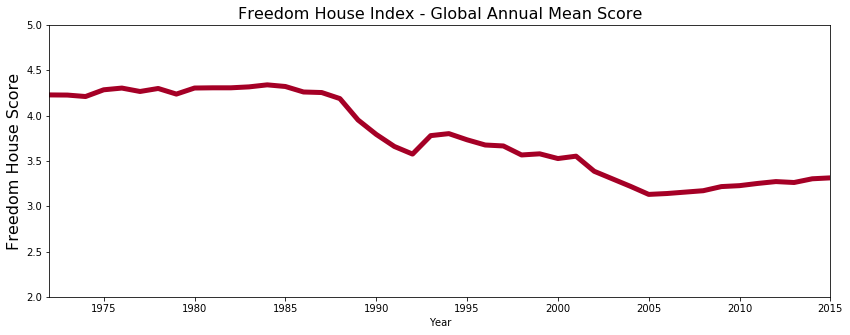

```python
df['mean'] = df.mean(axis=1)
df['mean'].plot(xlim=(1972, 2015),ylim=(2, 5), figsize=(14,5), linewidth=5, colormap='RdYlGn')
plt.title('Freedom House Index - Global Annual Mean Score', fontsize=16)
plt.xlabel('Year')
plt.ylabel('Freedom House Score', fontsize=16)
plt.savefig('fh_index_global_mean.png')
```

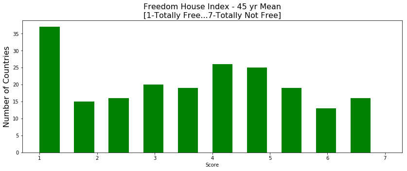

```python
df.mean().hist(figsize=(14,5), grid='off', width=.35, color ='g')
plt.title('Freedom House Index - 45 yr Mean\n[1-Totally Free...7-Totally Not Free]', fontsize=16)
plt.ylabel('Number of Countries', fontsize=16)
plt.xlabel('Score')
plt.savefig('fh_bar_mean.pdf')
```

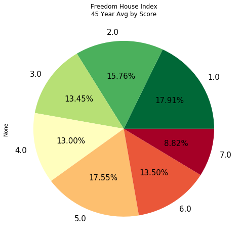

```python
df2.mean(axis=1).plot(kind='pie', title='Freedom House Index\n45 Year Avg by Score', autopct='%.2f%%', fontsize=15, figsize=(8,8),colormap='RdYlGn_r')
plt.savefig('fh_pie_mean.png')
```

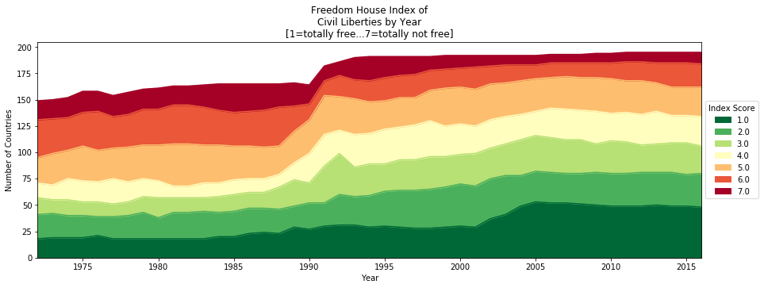

```python
df2.T.plot(kind='area', figsize=(15,5),title='Freedom House Index of\nCivil Liberties by Year\n[1=totally free...7=totally not free]', colormap='RdYlGn_r')
plt.legend(loc='center left', bbox_to_anchor=(1.0, 0.5), title='Index Score')
plt.xlabel('Year')
plt.ylabel('Number of Countries')
plt.savefig('fh_area_mean.png')
```

[figure not shown]

```python
# drilling into 85-15 period
df2.T[15:].plot(figsize=(14,5), title='Freedom House Index - 1985-2016', colormap='RdYlGn', linewidth=5)
plt.legend(loc='center left', bbox_to_anchor=(1.0, 0.5), title='Index Score')
plt.xlabel('Year')
plt.ylabel('Countries')
plt.savefig('breakout_82_93_mean.png')
```

> Limitations of the Research
> - key: multiple factors influence civil liberties and political rights

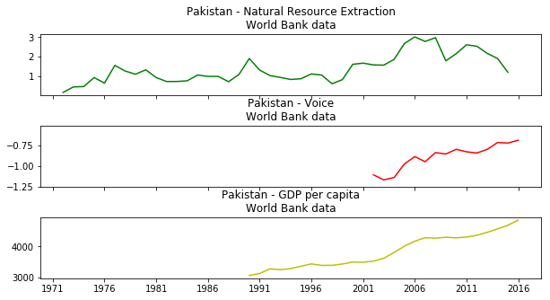

```python
# country picker
df3 = fhfawb
mon = df3[df3['country'] == 'Pakistan']
f, (ax1, ax2, ax3) = plt.subplots(3, sharex=True, sharey=False, figsize=(10,5))
ax1.plot(mon.date, mon.nat, color='g')
ax1.set_title('Pakistan - Natural Resource Extraction\nWorld Bank data')
ax2.plot(mon.date, mon.voice, color='r')
ax2.set_title('Pakistan - Voice\nWorld Bank data')
ax3.plot(mon.date, mon.gdppc, color='y')
ax3.set_title('Pakistan - GDP per capita\nWorld Bank data')
f.subplots_adjust(hspace=.5)
plt.setp([a.get_xticklabels() for a in f.axes[:-1]], visible=False)
plt.savefig('fh_tripart_mean.png')
```

## Question 3 - How has US foreign aid on democratic development (DRG) been spent?

> Spending Trends by Freedom

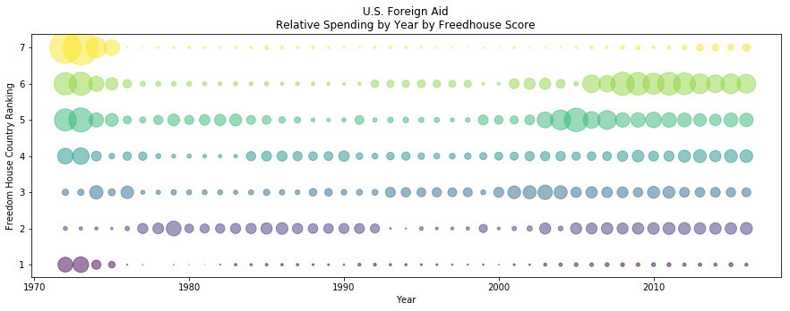

```python
dfq3 = fhfawb[(fhfawb.FH_Score == 'CL')&(fhfawb.FH_Score == 'CL')].groupby(['year', 'FH_value'])[['constant_amount']].sum().reset_index()

dfq3.FH_value = dfq3.FH_value.replace('-',np.nan).sort_values().astype(float)

x = dfq3.year
y = dfq3.FH_value
colors = dfq3.FH_value
areax = dfq3.constant_amount
area = (areax-min(areax))/(max(areax)-min(areax))*1500  # 0 to 15 point radii times 100
plt.figure(figsize=(15, 5))
plt.scatter(x, y, s=area,  c=colors, alpha=0.5)
plt.xlabel('Year')
plt.ylabel('Freedom House Country Ranking')
plt.title('U.S. Foreign Aid\nRelative Spending by Year by Freedhouse Score')
plt.savefig('FA_spending_by_year.png')
```

> Who spends the money?

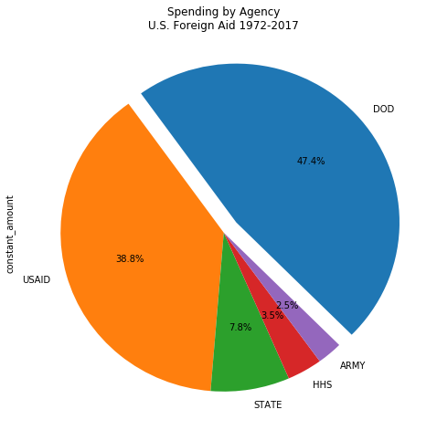

```python
Y_filt = fhfawb[(fhfawb.year > 1972)&(fhfawb.transaction_type_name == 'Disbursements')]
s_agency_cat= Y_filt \
.groupby(['implementing_agency_acronym'])[['constant_amount','FH_value']].sum() \
.constant_amount.sort_values(ascending=False)
explode = (.1,0,0,0,0)
plt.figure(figsize=(8,8))
s_agency_cat.head(5).plot(title='Spending by Agency\nU.S. Foreign Aid 1972-2017', \
                           kind='pie', autopct='%1.1f%%', explode=explode, startangle=-45);
# plt.ylabel('Percentage of Total')
plt.savefig('spending_pie_pct.png')
```

> And then Who Spends the Money?

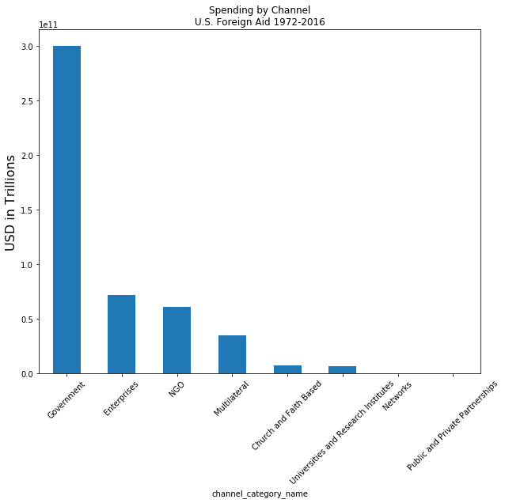

```python
CL_filt = fhfawb[(fhfawb.FH_Score == 'CL')&(fhfawb.transaction_type_name == 'Disbursements')]
df_chan_cat= CL_filt \
.groupby(['channel_category_name'])[['constant_amount','FH_value']].sum()

df_chan_cat = df_chan_cat.sort_values(by='constant_amount', ascending=False)

df_chan_cat.constant_amount.head(10).plot(kind='bar', figsize=(10,8))
plt.title('Spending by Channel\nU.S. Foreign Aid 1972-2016')
plt.ylabel('USD in Trillions', fontsize=16)
plt.xticks(rotation=45);
plt.savefig('spending_channel_bar.png')
```

> What is the Money Spent on?

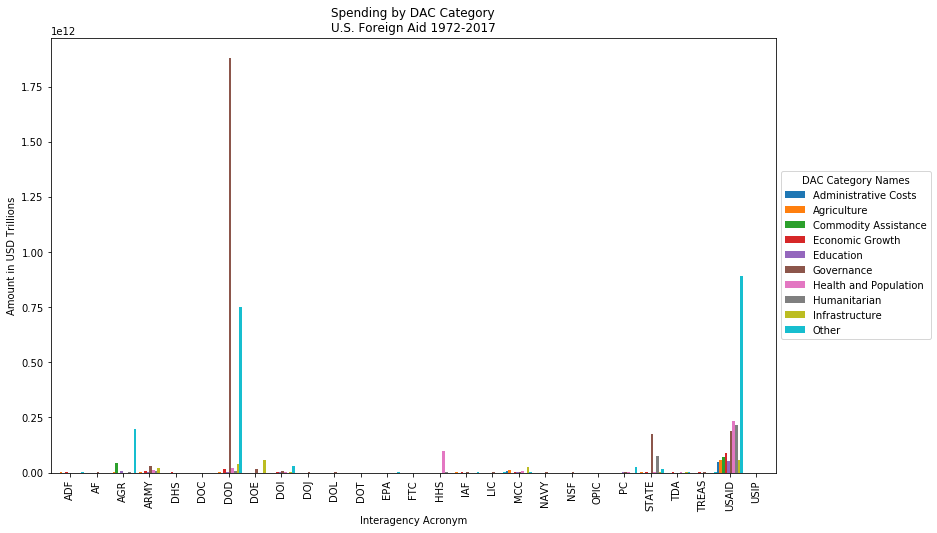

```python
R_filt = fhfawb[(fhfawb.year > 1972)]
s_agency_dac_cat = R_filt \
.groupby(['implementing_agency_acronym','dac_category_name'])[['constant_amount','FH_value']].sum()

s_agency_dac_cat.head()

pivtest = s_agency_dac_cat.reset_index()
pt = pivtest.pivot(index='implementing_agency_acronym', columns='dac_category_name', values='constant_amount')
pt = pt.fillna(0)
pt.apply(lambda x: 100 * x / float(x.sum()))
pt.plot(kind='bar', figsize=(13,8), width=1, title='Spending by DAC Category\nU.S. Foreign Aid 1972-2017')
plt.legend(loc='center left', bbox_to_anchor=(1.0, 0.5), title='DAC Category Names')
plt.ylabel('Amount in USD Trillions')
plt.xlabel('Interagency Acronym');
plt.savefig('spending_by_dac.png')
```

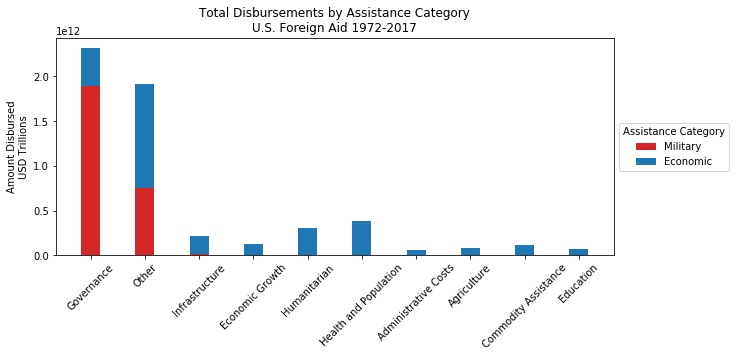

```python
Y_filt = fhfawb[(fhfawb.year > 1972)]
df_dac_cat_econmil = Y_filt \
.groupby(['dac_category_name','assistance_category_name'])[['constant_amount','FH_value']].sum()

df_dac2_econmil_table = df_dac_cat_econmil.reset_index()\
.pivot(index= 'dac_category_name',columns =  'assistance_category_name', values = 'constant_amount')\
.reset_index()

df_dac2_econmil_table.columns = ['dac_category_name','economic','military']

df_dac2_econmil_table= df_dac2_econmil_table.fillna(0).sort_values(by='military',ascending=False)

N = 10
Military = df_dac2_econmil_table.military
Economic = df_dac2_econmil_table.economic

ind = np.arange(N)    # the x locations for the groups
width = 0.35       # the width of the bars: can also be len(x) sequence

plt.figure(figsize=(10,4))
p1 = plt.bar(ind, Military, width, color='#d62728',)
p2 = plt.bar(ind, Economic, width,
             bottom=Military)

plt.ylabel('Amount Disbursed\nUSD Trillions')
plt.title('Total Disbursements by Assistance Category\nU.S. Foreign Aid 1972-2017')
plt.xticks(ind, df_dac2_econmil_table.dac_category_name, rotation=45)
plt.legend((p1[0], p2[0]), ('Military', 'Economic'), loc='center left', bbox_to_anchor=(1.0, 0.5), title='Assistance Category');
plt.savefig('spending_by_asst_cat.png')
```

# Question - 4 Purpose: Does Aid Lead to Democratic Outcomes?

- general
- country specific

> years a country was in a particular category

> Country volatility and spending

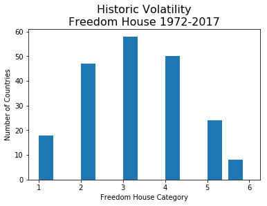

```python
check = fhfawb[fhfawb.FH_Score == 'CL'].groupby(['country', 'FH_value'])[['FH_value']].count()

check.columns = [['FH_values']]

check.reset_index().groupby('country')[['FH_value']].count() \
.rename(columns={'FH_value':'FH_cat_range'}).hist(grid='False', width=.35)
plt.xlabel('Freedom House Category')
plt.ylabel('Number of Countries')
plt.title('Historic Volatility\nFreedom House 1972-2017',fontsize=16);
plt.savefig('hist_volatility.png')
```

```python
check = check.reset_index().groupby('country')[['FH_value']].count().rename(columns={'FH_value':'FH_cat_volatility'})
check.head()

# this is the table for the histogram above
check_table = check.groupby('FH_cat_volatility')[['FH_cat_volatility']].count()

check = check.reset_index().sort_values(by='FH_cat_volatility',ascending=False)
check.set_index('country').head(10)
```

| country | FH_cat_volatility |
| --- | --- |
| Cabo Verde | 6 |
| Argentina | 6 |
| Benin | 6 |
| Grenada | 6 |
| Hungary | 6 |
| Romania | 6 |
| Poland | 6 |
| Mali | 6 |
| Suriname | 5 |
| Congo, Rep. | 5 |

> Historic Volatility and Spending

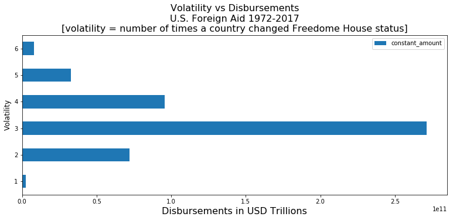

```python
vol_spend = fhfawb[(fhfawb.FH_Score == 'CL') & (fhfawb.transaction_type_name == 'Disbursements')].groupby(['country'])[['constant_amount']].sum()

vol_spend = vol_spend.reset_index().sort_values(by='country')

vol_spend = vol_spend.merge(check, how='left', on='country').sort_values(by='FH_cat_volatility', ascending=False)

vol_spend.FH_cat_volatility = vol_spend.FH_cat_volatility.astype('category')

vol_spend_cht = vol_spend.groupby(['FH_cat_volatility'])[['constant_amount']].sum()
vol_spend_cht.plot(kind='barh', figsize=(13,5))
plt.title('Volatility vs Disbursements\nU.S. Foreign Aid 1972-2017\n[volatility = number of times a country changed Freedome House status]', fontsize=16)
plt.ylabel('Volatility',fontsize=12)
plt.xlabel('Disbursements in USD Trillions', fontsize=16);
plt.savefig('hist_volatility_disp.png')
```

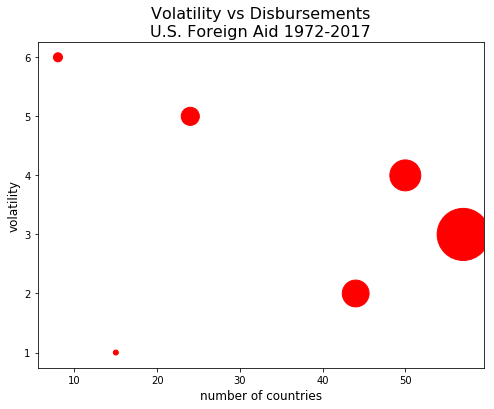

```python
vol_spend_bub = vol_spend.groupby('FH_cat_volatility').sum().reset_index()
vol_spend_bub['countries'] = vol_spend.groupby('FH_cat_volatility').count().reset_index().country
x=vol_spend_bub['countries']
y=vol_spend_bub['FH_cat_volatility']
s=vol_spend_bub['constant_amount']/100000000
plt.figure(figsize=(8,6))
plt.scatter(x,y,s=s, c='r')
plt.title('Volatility vs Disbursements\nU.S. Foreign Aid 1972-2017',fontsize=16)
plt.ylabel('volatility', fontsize=12)
plt.xlabel('number of countries', fontsize=12);
plt.savefig('hist_volatility_bub.png')
```

> Correlation between Change in Freedom Score and USD Spending
> - Insignificant in general

```python
diff_s.corr()
```

|  | FH_value | constant_amount |
| --- | --- | --- |
| FH_value | 1.000000 | 0.020344 |
| constant_amount | 0.020344 | 1.000000 |

> Correlation between Change in Freedom Score and USD Spending
> - At a Country Level in Volatile Countries
> - Examples

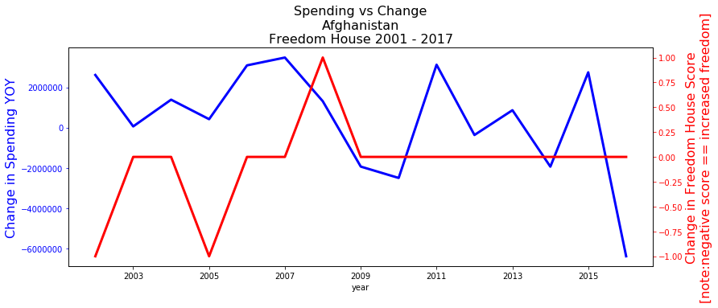

```python
COUNTRY_NAME = 'Afghanistan'

diff_s_af = diff_s
diff_s_af = diff_s[diff_s.country == COUNTRY_NAME]
fig, ax1 = plt.subplots(figsize=(13,5))
t = diff_s_af.year
s1 = diff_s_af.constant_amount
ax1.plot(t, s1, 'b', linewidth=3.0)
ax1.set_xlabel('year')
# Make the y-axis label, ticks and tick labels match the line color.
ax1.set_ylabel('Change in Spending YOY', color='b', fontsize=16)
ax1.tick_params('y', colors='b')

ax2 = ax1.twinx()
s2 = diff_s_af.FH_value
ax2.plot(t, s2, 'r', linewidth=3.0)
ax2.set_ylabel('Change in Freedom House Score\n[note:negative score == increased freedom]', color='r', fontsize=16)
ax2.tick_params('y', colors='r')
fig.savefig('test.jpg')
plt.title('Spending vs Change\n{}\nFreedom House 2001 - 2017'.format(COUNTRY_NAME), color='k', fontsize=16);
plt.savefig('{}.png'.format(COUNTRY_NAME))
```

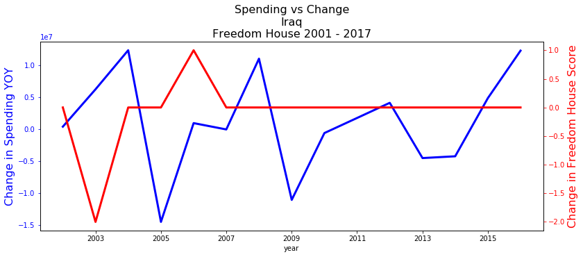

```python
COUNTRY_NAME = 'Iraq'

diff_s_af = diff_s
diff_s_af = diff_s[diff_s.country == COUNTRY_NAME]
fig, ax1 = plt.subplots(figsize=(13,5))
t = diff_s_af.year
s1 = diff_s_af.constant_amount
ax1.plot(t, s1, 'b', linewidth=3.0)
ax1.set_xlabel('year')
# Make the y-axis label, ticks and tick labels match the line color.
ax1.set_ylabel('Change in Spending YOY', color='b', fontsize=16)
ax1.tick_params('y', colors='b')

ax2 = ax1.twinx()
s2 = diff_s_af.FH_value
ax2.plot(t, s2, 'r', linewidth=3.0)
ax2.set_ylabel('Change in Freedom House Score', color='r', fontsize=16)
ax2.tick_params('y', colors='r')
fig.savefig('test.jpg')
plt.title('Spending vs Change\n{}\nFreedom House 2001 - 2017'.format(COUNTRY_NAME), color='k', fontsize=16);
plt.savefig('{}.png'.format(COUNTRY_NAME))
```

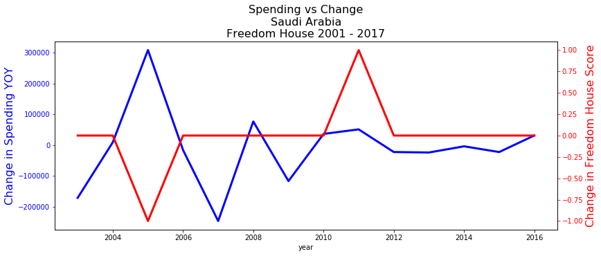

```python
COUNTRY_NAME = 'Saudi Arabia'

diff_s_af = diff_s
diff_s_af = diff_s[diff_s.country == COUNTRY_NAME]
fig, ax1 = plt.subplots(figsize=(13,5))
t = diff_s_af.year
s1 = diff_s_af.constant_amount
ax1.plot(t, s1, 'b', linewidth=3.0)
ax1.set_xlabel('year')
# Make the y-axis label, ticks and tick labels match the line color.
ax1.set_ylabel('Change in Spending YOY', color='b', fontsize=16)
ax1.tick_params('y', colors='b')

ax2 = ax1.twinx()
s2 = diff_s_af.FH_value
ax2.plot(t, s2, 'r', linewidth=3.0)
ax2.set_ylabel('Change in Freedom House Score', color='r', fontsize=16)
ax2.tick_params('y', colors='r')
fig.savefig('test.jpg')
plt.title('Spending vs Change\n{}\nFreedom House 2001 - 2017'.format(COUNTRY_NAME), color='k', fontsize=16);
plt.savefig('{}.png'.format(COUNTRY_NAME))
```